# Evidencia 2

Alan Urie Merlan Esquivel

`06/05/2022`

##Parte 1

**PRESENTACION** https://docs.google.com/presentation/d/1l0YJrtAPaV2qdWO_ebhWTpX-EpduJH-6/edit?usp=sharing&ouid=102547863662586450575&rtpof=true&sd=true

**VIDEO** https://www.youtube.com/watch?v=Vj0MbMA9Gp4

**Las preguntas contienen lo mismo que la presentación y el video.** ¿Cuáles son los virus “similares” a SARS-CoV-2 en el mundo? Obtén tus referencias de PUBMED.

ncontrado en el articulo de Alexande Thomas en Virus del MDPI, articulo disponible en Pub Med Central(https://www.ncbi.nlm.nih.gov/pmc/articles/PMC8402765/) El coronavirus cuenta con muchos parientes “similares” en cierta medida Este proviene de cornaviridae, que a su vez se divide coronavirinae que a su vez se divide en : - Alphacoronavirus - Betacoronavirus(Aqusí se encuentra el SARS-CoV2) - Gammacoronavirus - Etc.

Virus similares al coronavirus y que también generan pandemias humanas. Según Pedro Souza en un articulo de International Journal of Biological Macromolecules, encontrado en pub med central(https://www.ncbi.nlm.nih.gov/pmc/articles/PMC7921731/) - SARS-Cov1 - Mers-Cov Por otra, parte los virus de la familia coronavirus que han efectado humanos pero que no cuentan con sucesos pandémicos y, en general, cuentan con menos similitudes son los siguientes - Los que al igual que los tres anteriores, permanecen en Betacoronavirus: HCoV-0C43, HCoV-KKU1 - Los que no: Hcov-NL63, CoV-229E Encontrado en el articulo de Alexande Thomas en Virus del MDPI, articulo disponible en Pub Med Central(https://www.ncbi.nlm.nih.gov/pmc/articles/PMC8402765/)

¿Cuáles son los coronavirus reportados en otras especies que pueden ser cercanos al genoma de SARS-CoV-2? Incluye de qué especies son y menciona las referencias de los artículos consultados en PUBMED.

Basado en una publicación de Devika Singh, encontrable en pub med(https://pubmed.ncbi.nlm.nih.gov/33864026/). Al igual que en el caso anterior hay una gran cantidad de variedad de coronavirus en especies diferentes a humnas. Algunas cercanas al Sars-Cov2 son - RatG13 en murciélagos - Guangdong 2019 en pangolines

Algunos otros ejemplos de coronavirus, no necesariamente similares al SARS-Cov-2. - PC4-13 en civeta común de las palmeras - Rs3367 en murciélagos - Etc.

En relación con la situación actual reflexiona, ¿qué propondrías que se deba hacer durante la contingencia del SARS-CoV-2 en comunidades de bajos recursos? Si tu vivieras en una situación de escasos recursos, ¿qué harías? Justifica tu respuesta.

En vista de que el panorama, según la ONU(2020), es de un incremento de la pobreza, desigualdad y una tendencia a una peor calidad de vida, considero que lo primero para evitar empeorar más la situación es invertir en programas de ayuda para esta población, facilitando la sanitización y brindado apoyos económicos . Por otra parte, en lo personal si me encontrará en una situación tan difícil, una donde incluso comprar un cubrebocas implica un gasto importante, intentaría economizar lo más posible el gasto de esté e intentar usarlo lo más que se pueda, pero priorizando el sustento económica para poder sobrevivir.

Referencias

- COVID, hambre, pobreza y desigualdad: la combinación mortal que. (2021, 11 octubre). Noticias ONU. Recuperado 6 de mayo de 2022, de https://news.un.org/es/story/2020/07/1477571
- Singh, D. (2021, 16 abril). On the origin and evolution of SARS-CoV-2. Pubmed. Recuperado 6 de mayo de 2022, de https://pubmed.ncbi.nlm.nih.gov/33864026/
- Souza, P. (2021, 15 mayo). The human pandemic coronaviruses on the show: The spike glycoprotein as the main actor in the coronaviruses play. PubMed Central. Recuperado 6 de mayo de 2022, de https://www.ncbi.nlm.nih.gov/pmc/articles/PMC7921731/
- Thomas Sampson, A. (2021, 13 agosto). Coronavirus Pseudotypes for All Circulating Human Coronaviruses for Quantification of Cross-Neutralizing Antibody Responses. PubMed Central. Recuperado 6 de mayo de 2022, de https://www.ncbi.nlm.nih.gov/pmc/articles/PMC8402765/

##Parte 2 **1. Analizar las secuencias de SARS-CoV-2 reportadas en los 20 países con más casos reportados. Y puedes tratar de responder a la pregunta: ¿Son muy diferentes las variantes entre cada país? ¿Es diferente el SARS-CoV-2 entre las diferentes poblaciones: Asiática, Hispana, Europea o Africana?**

```r
library("seqinr")
library("datasets")
library("ggplot2")
library("Biostrings")
library("ape")
library("phangorn")
library("ggtree")
library("DECIPHER")
library("viridis")
library("ade4")
library("ggmsa")
Alemania <- read.fasta("ALEMANIA.fasta")
Argentina <-read.fasta("ARGENTINA.fasta")
Australia <-read.fasta("AUSTRALIA.fasta")
Brasil <- read.fasta("BRASIL.fasta")
Colombia <-read.fasta("COLOMBIA.fasta")
CoreaDelSur <-read.fasta("COREADELSUR.fasta")
Espana <-read.fasta("ESPANA.fasta")
Francia <-read.fasta("FRANCIA.fasta")
India <-read.fasta("INDIA.fasta")
Indonesia <-read.fasta("INDONESIA.fasta")
Iran <-read.fasta("IRAN.fasta")
Italia <-read.fasta("ITALIA.fasta")
Japon <-read.fasta("JAPON.fasta")
PaisesBajos <-read.fasta("PAISESBAJOS.fasta")
Polonia <-read.fasta("POLONIA.fasta")
ReinoUnido <-read.fasta("REINOUNIDO.fasta")
Rusia <-read.fasta("RUSIA.fasta")
Turquia <-read.fasta("TURQUIA.fasta")
Usa <-read.fasta("USA.fasta")
Vietnam <-read.fasta("VIETNAM.fasta")
a <- c(Alemania, Argentina, Australia, Brasil, Colombia, CoreaDelSur, Espana, Francia, India, Indonesia, Iran, Italia, Japon, PaisesBajos, Polonia, ReinoUnido, Rusia, Turquia, Usa, Vietnam)
nombres <- c("Alemania", "Argentina", "Australia", "Brasil", "Colombia", "CoreaDelSur", "Espana", "Francia", "India", "Indonesia", "Iran", "Italia", "Japon", "PaisesBajos", "Polonia", "ReinoUnido", "Rusia", "Turquia", "Usa", "Vietnam")
```

**2. Calcula la longitud de las secuencias que incluyas**

```r
for (i in 1:length(a)){
  print(nombres[i])
  print(length(a[[i]]))
}
```

```
## [1] "Alemania"
## [1] 29431
## [1] "Argentina"
## [1] 29785
## [1] "Australia"
## [1] 29378
## [1] "Brasil"
## [1] 29824
## [1] "Colombia"
## [1] 29769
## [1] "CoreaDelSur"
## [1] 29648
## [1] "Espana"
## [1] 29783
## [1] "Francia"
```

[output cut: 25 more lines]

**3. Crea una sola gráfica donde se comparen el número de bases de ADN que componen todas las variantes del virus.**

```r
i <- c()
alan <- c()

for (n in 1:length(a)){
  m <- (count(a[[n]], 1))
  print(m)
    for (j in 1:4) {
    i <- c(i,m[[j]])

    }
  alan <- c(alan,i)
  i <- c()
}
```

```
##
##    a    c    g    t
## 8805 5370 5768 9488
##
##    a    c    g    t
## 8902 5457 5836 9585
##
##    a    c    g    t
## 8781 5372 5757 9468
##
##    a    c    g    t
## 8903 5474 5850 9597
##
##    a    c    g    t
## 8888 5460 5845 9576
##
##    a    c    g    t
## 8859 5426 5817 9546
##
##    a    c    g    t
## 8898 5454 5838 9593
##
##    a    c    g    t
## 8881 5430 5824 9572
##
##    a    c    g    t
## 8894 5463 5848 9589
##
##    a    c    g    t
## 8891 5454 5842 9589
##
##    a    c    g    t
## 8948 5459 5856 9613
##
##    a    c    g    t
## 8842 5416 5800 9550
##
##    a    c    g    t
## 8893 5450 5839 9563
##
##    a    c    g    t
## 8812 5381 5779 9496
##
##    a    c    g    t
## 8862 5438 5822 9553
##
##    a    c    g    t
## 8897 5444 5837 9593
##
##    a    c    g    t
## 8881 5454 5832 9571
##
##    a    c    g    t
## 8874 5447 5827 9571
##
##    a    c    g    t
## 8874 5439 5821 9546
##
##    a    c    g    t
## 8891 5455 5846 9577
```

```r
df2<-data.frame(Variantes=c(rep(c("Alemania"), 4), rep(c("Argentina"), 4), rep(c("Australia"), 4), rep(c("Brasil"), 4), rep(c("Colombia"), 4), rep(c("CoreaDelSur"), 4), rep(c("Espana"), 4), rep(c("Francia"), 4), rep(c("India"), 4), rep(c("Indonesia"), 4), rep(c("Iran"), 4), rep(c("Italia"), 4), rep(c("Japon"), 4), rep(c("PaisesBajos"), 4), rep(c("Polonia"), 4), rep(c("ReinoUnido"), 4), rep(c("Rusia"), 4), rep(c("Turquia"), 4), rep(c("Usa"), 4), rep(c("Vietnam"), 4))
,Nucleotidos=rep(c("Adenina", "Timina", "Citosina", "Guanina"), 5),Frecuencia=alan)

p1 <- ggplot(df2, aes(Nucleotidos,Frecuencia,fill=Variantes)) +
  geom_bar(stat = "identity", position = "dodge", color = "black")
  labs(title = "Nucleótidos en SARS-CoV-2 detectado en 20 países")  +
  theme(legend.position = "bottom")
```

[figure not shown]

```r
p1 + theme_linedraw()
```

**4. Agrega un análisis jerárquico global obtenido de las secuencias que se seleccionaron para estudiar.**

```r
write.dna(a,
          file ="virus_secuencias.fasta",
          format = "fasta",
          append = FALSE,
          nbcol = 6,
          colsep = " ",
          colw = 10)

virus_secuen_no_alin <- readDNAStringSet("virus_secuencias.fasta", format = "fasta")
virus_secuen_no_alin
```

```
## DNAStringSet object of length 20:
##      width seq                                              names
##  [1] 29431 GAAAGGTAAGATGGAGAGCCTTG...GTAACATTAGGGAGGACTTGAA hCoV-19/Germany/N...
##  [2] 29785 GGTTTATACCTTCCTAGGTAACA...GCTATCCCCATGTGATTTTAAT hCoV-19/Argentina...
##  [3] 29378 TGGAGAGCCTTGTCCCTGGTTTC...AGTTAACTTTAATCTCACATAG hCoV-19/Australia...
##  [4] 29824 CCAACTTTCGATCTCTTGTAGAT...CATGTGATTTTAATAGCTTCTT hCoV-19/Brazil/SC...
##  [5] 29769 AGATCTGTTCTCTAAACGAACTT...ATTAATTTTAGTAGTGCTATCC hCoV-19/Colombia/...
##  ...   ... ...
## [16] 29772 TAAAGGTTTATACCTTCCCAGGT...ATGTGTAAAATTAATTTTAGTA hCoV-19/Scotland/...
## [17] 29738 TCCCAGGTAACAAACCAACCAAC...GTACGATCGAGTGTACAGTGAA hCoV-19/Russia/MO...
## [18] 29719 AAACCAACCAACTTTCGATCTCT...AATGCTAGGGAGAGCTGCCTAT hCoV-19/Turkey/HS...
## [19] 29693 AGATCTGTTCTCTAAACGAACTT...GTACGATCGAGTGTACAGTGAA hCoV-19/USA/NV-NS...
## [20] 29769 GATCTGTTCTCTAAACGAACTTT...TTAATTTTAGTAGTGCTATCCC hCoV-19/Vietnam/N...
```

```r
virus_secuen_no_alin <- OrientNucleotides(virus_secuen_no_alin)
```

```
## ========================================================================================================================================================================================================
##
## Time difference of 0.55 secs
```

```r
virus_secuen_alin <- AlignSeqs(virus_secuen_no_alin)
```

```
## Determining distance matrix based on shared 11-mers:
## ================================================================================
##
## Time difference of 0.05 secs
##
## Clustering into groups by similarity:
## ================================================================================
##
## Time difference of 0.01 secs
##
## Aligning Sequences:
## ================================================================================
##
## Time difference of 2.74 secs
##
## Iteration 1 of 2:
##
## Determining distance matrix based on alignment:
## ================================================================================
##
## Time difference of 0.02 secs
##
## Reclustering into groups by similarity:
## ================================================================================
##
## Time difference of 0.01 secs
##
## Realigning Sequences:
## ================================================================================
##
## Time difference of 3.44 secs
##
## Iteration 2 of 2:
##
## Determining distance matrix based on alignment:
## ================================================================================
##
## Time difference of 0.02 secs
##
## Reclustering into groups by similarity:
## ================================================================================
##
## Time difference of 0.02 secs
##
## Realigning Sequences:
## ================================================================================
##
## Time difference of 0.02 secs
```

```r
BrowseSeqs(virus_secuen_alin, highlight=0)

writeXStringSet(virus_secuen_alin, file="virus_secuen_alin.fasta")

virus_alin <- read.alignment("virus_secuen_alin.fasta", format = "fasta")

matriz_distancia <- dist.alignment(virus_alin, matrix = "similarity")

virus_arbol <- nj(matriz_distancia)
class(virus_arbol)
```

```
## [1] "phylo"
```

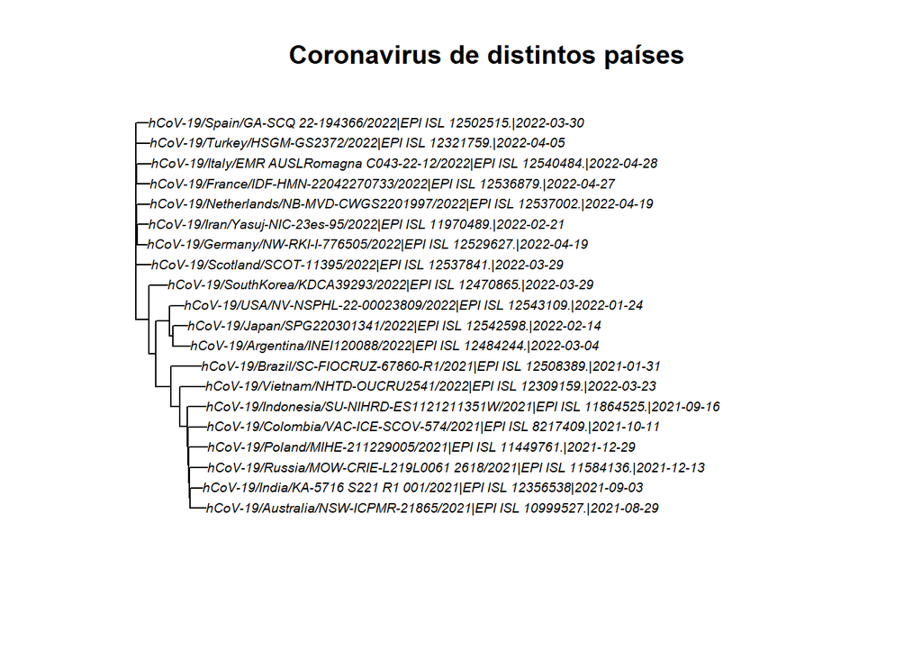

```r
virus_arbol <- ladderize(virus_arbol)

plot(virus_arbol, cex = 0.6)
title("Coronavirus de distintos países")
```

**5o.Agrega una interpretación escrita de tus gráficas y tus conclusiones según el caso de estudio que seleccionaste. No olvides sustentar tus argumentos con las lecturas que realizaste.** En la primera gráfica, se muestra la cantidad de nucleótidos por cada país, en esta se observa como los niveles de adenina, citosina, guanina y timina en cada variante por país se mantienen prácticamente iguales. Por tanto, las secuencias son muy parecidas entre países. De manera que, las diferencias entre síntomas y contagiosidad dadas entre todas las variantes es dada por esa pequeña diferencia.

Cabe mencionar que, lo anterior tambien es observable en: Iran y Turquia; así como en India y Rusia.

Por otra parte, se observa lo contrario con Australia, la variante de esta en la gráfica es la más alejada al inicio del árbol. De manera que se observa, como la distancia entre países conlleva que las variantes similares presentes en Europa no predominen de la misma manera.

Otra cosa que se llega a observar en la gráfica es que países con lejanía cuenten con variantes similares. Tal es el caso de Japón y Argentina, los cuales, pese a su distancia geográfica entre ellos, cuentan con ramas muy cercanas en el árbol. Esto se podría atribuir a varias razones sin embargo, el caso más probable es que la variante que se escogió de alguno de los países no corresponda a una similar a la predominante y provenga de un ligera interacción entre países, de manera que sea simplemente un comparación puntual que no demuestra nada en específico.

Cabe destacar, que el ultimo caso mencionado es el más común entre los paíes, por ejemplo pasa algo similar con USA,Japon y Sur COrea; o entre Colombia y Polonia.

```r
citation("seqinr")
```

```
##
##
##   Charif, D. and Lobry, J.R. (2007)
##
## A BibTeX entry for LaTeX users is
##
##   @InCollection{,
##     author = {D. Charif and J.R. Lobry},
##     title = {Seqin{R} 1.0-2: a contributed package to the {R} project for statistical computing devoted to biological sequences retrieval and analysis.},
##     booktitle = {Structural approaches to sequence evolution: Molecules, networks, populations},
##     year = {2007},
##     editor = {U. Bastolla and M. Porto and H.E. Roman and M. Vendruscolo},
##     series = {Biological and Medical Physics, Biomedical Engineering},
##     pages = {207-232},
##     address = {New York},
##     publisher = {Springer Verlag},
##     note = {{ISBN :} 978-3-540-35305-8},
##   }
```

```r
citation("datasets")
```

```
##
## The 'datasets' package is part of R.  To cite R in publications use:
##
##   R Core Team (2022). R: A language and environment for statistical
##   computing. R Foundation for Statistical Computing, Vienna, Austria.
##   URL https://www.R-project.org/.
##
## A BibTeX entry for LaTeX users is
##
##   @Manual{,
##     title = {R: A Language and Environment for Statistical Computing},
##     author = {{R Core Team}},
##     organization = {R Foundation for Statistical Computing},
##     address = {Vienna, Austria},
##     year = {2022},
##     url = {https://www.R-project.org/},
##   }
##
## We have invested a lot of time and effort in creating R, please cite it
## when using it for data analysis. See also 'citation("pkgname")' for
## citing R packages.
```

```r
citation("ggplot2")
```

```
##
##
##   H. Wickham. ggplot2: Elegant Graphics for Data Analysis.
##   Springer-Verlag New York, 2016.
##
## A BibTeX entry for LaTeX users is
##
##   @Book{,
##     author = {Hadley Wickham},
##     title = {ggplot2: Elegant Graphics for Data Analysis},
##     publisher = {Springer-Verlag New York},
##     year = {2016},
##     isbn = {978-3-319-24277-4},
##     url = {https://ggplot2.tidyverse.org},
##   }
```

```r
citation("Biostrings")
```

```
##
##
##   H. Pagès, P. Aboyoun, R. Gentleman and S. DebRoy (2021). Biostrings:
##   Efficient manipulation of biological strings. R package version
##   2.62.0. https://bioconductor.org/packages/Biostrings
##
## A BibTeX entry for LaTeX users is
##
##   @Manual{,
##     title = {Biostrings: Efficient manipulation of biological strings},
##     author = {H. Pagès and P. Aboyoun and R. Gentleman and S. DebRoy},
##     year = {2021},
##     note = {R package version 2.62.0},
##     url = {https://bioconductor.org/packages/Biostrings},
##   }
##
## ATTENTION: This citation information has been auto-generated from the
## package DESCRIPTION file and may need manual editing, see
## 'help("citation")'.
```

```r
citation("ape")
```

```
##
##
##   Paradis E. & Schliep K. 2019. ape 5.0: an environment for modern
##   phylogenetics and evolutionary analyses in R. Bioinformatics 35:
##   526-528.
##
## A BibTeX entry for LaTeX users is
##
##   @Article{,
##     title = {ape 5.0: an environment for modern phylogenetics and evolutionary analyses in {R}},
##     author = {E. Paradis and K. Schliep},
##     journal = {Bioinformatics},
##     year = {2019},
##     volume = {35},
##     pages = {526-528},
##   }
##
## As ape is evolving quickly, you may want to cite also its version
## number (found with 'library(help = ape)' or 'packageVersion("ape")').
```

```r
citation("ggtree")
```

```
##
##
##   Guangchuang Yu. Using ggtree to visualize data on tree-like
##   structures. Current Protocols in Bioinformatics, 2020, 69:e96. doi:
##   10.1002/cpbi.96
##
##   Guangchuang Yu, Tommy Tsan-Yuk Lam, Huachen Zhu, Yi Guan. Two methods
##   for mapping and visualizing associated data on phylogeny using
##   ggtree. Molecular Biology and Evolution 2018, 35(2):3041-3043. doi:
##   10.1093/molbev/msy194
##
##   Guangchuang Yu, David Smith, Huachen Zhu, Yi Guan, Tommy Tsan-Yuk
##   Lam. ggtree: an R package for visualization and annotation of
##   phylogenetic trees with their covariates and other associated data.
##   Methods in Ecology and Evolution 2017, 8(1):28-36.
##   doi:10.1111/2041-210X.12628
##
## To see these entries in BibTeX format, use 'print(<citation>,
## bibtex=TRUE)', 'toBibtex(.)', or set
## 'options(citation.bibtex.max=999)'.
```

```r
citation("DECIPHER")
```

```
##
## Wright ES (2016). "Using DECIPHER v2.0 to Analyze Big Biological
## Sequence Data in R." _The R Journal_, *8*(1), 352-359.
##
## A BibTeX entry for LaTeX users is
##
##   @Article{,
##     title = {Using DECIPHER v2.0 to Analyze Big Biological Sequence Data in R},
##     author = {Erik S. Wright},
##     journal = {The R Journal},
##     year = {2016},
##     volume = {8},
##     number = {1},
##     pages = {352-359},
##   }
```

```r
citation("viridis")
```

```
##
##
##   Simon Garnier, Noam Ross, Robert Rudis, Antônio P. Camargo, Marco
##   Sciaini, and Cédric Scherer (2021). Rvision - Colorblind-Friendly
##   Color Maps for R. R package version 0.6.2.
##
## A BibTeX entry for LaTeX users is
##
##   @Manual{,
##     title = {{viridis} - Colorblind-Friendly Color Maps for R},
##     author = {{Garnier} and {Simon} and {Ross} and {Noam} and {Rudis} and {Robert} and {Camargo} and Antônio Pedro and {Sciaini} and {Marco} and {Scherer} and {Cédric}},
##     year = {2021},
##     note = {R package version 0.6.2},
##     url = {https://sjmgarnier.github.io/viridis/},
##     doi = {10.5281/zenodo.4679424},
##     doi = {10.5281/zenodo.4679424},
##   }
```

```r
citation("phangorn")
```

```
##
## Use 2011 to cite phangorn in a publication; 2017 for plotting
## phylogenetic networks. As phangorn is evolving quickly, you may want to
## cite also its version number (phangorn 2.8.1).
##
##   Schliep K.P. 2011. phangorn: phylogenetic analysis in R.
##   Bioinformatics, 27(4) 592-593
##
##   Schliep, K., Potts, A. J., Morrison, D. A., Grimm, G. W. (2017),
##   Intertwining phylogenetic trees and networks. Methods in Ecology and
##   Evolution, 8: 1212--1220. doi: 10.1111/2041-210X.12760
##
## To see these entries in BibTeX format, use 'print(<citation>,
## bibtex=TRUE)', 'toBibtex(.)', or set
## 'options(citation.bibtex.max=999)'.
```

```r
citation("ade4")
```

```
##
##
## Dray S, Dufour A (2007). "The ade4 Package: Implementing the Duality
## Diagram for Ecologists." _Journal of Statistical Software_, *22*(4),
## 1-20. doi: 10.18637/jss.v022.i04 (URL:
## https://doi.org/10.18637/jss.v022.i04).
##
## Bougeard S, Dray S (2018). "Supervised Multiblock Analysis in R with
## the ade4 Package." _Journal of Statistical Software_, *86*(1), 1-17.
## doi: 10.18637/jss.v086.i01 (URL:
## https://doi.org/10.18637/jss.v086.i01).
##
## Chessel D, Dufour A, Thioulouse J (2004). "The ade4 Package - I:
## One-Table Methods." _R News_, *4*(1), 5-10. <URL:
## https://cran.r-project.org/doc/Rnews/>.
##
## Dray S, Dufour A, Chessel D (2007). "The ade4 Package - II: Two-Table
## and K-Table Methods." _R News_, *7*(2), 47-52. <URL:
## https://cran.r-project.org/doc/Rnews/>.
##
## Thioulouse J, Dray S, Dufour A, Siberchicot A, Jombart T, Pavoine S
## (2018). _Multivariate Analysis of Ecological Data with ade4_. Springer.
## doi: 10.1007/978-1-4939-8850-1 (URL:
## https://doi.org/10.1007/978-1-4939-8850-1).
##
## To see these entries in BibTeX format, use 'print(<citation>,
## bibtex=TRUE)', 'toBibtex(.)', or set
## 'options(citation.bibtex.max=999)'.
```

```r
citation("ggmsa")
```

```
##
##
##   Lang Zhou and Guangchuang Yu (2021). ggmsa: Plot Multiple Sequence
##   Alignment using 'ggplot2'. R package version 1.0.0.
##   http://yulab-smu.top/ggmsa/
##
## A BibTeX entry for LaTeX users is
##
##   @Manual{,
##     title = {ggmsa: Plot Multiple Sequence Alignment using 'ggplot2'},
##     author = {Lang Zhou and Guangchuang Yu},
##     year = {2021},
##     note = {R package version 1.0.0},
##     url = {http://yulab-smu.top/ggmsa/},
##   }
```